# Repetition analyses (RT)

Hannah, 6/30/2017

**Major changes: Fixed FlankerRep and TargetRep to include duplications (e.g., 130 followed by 130). Added model with TargetRep included as covariate.**

### 1. REACTION TIME

Uses RT data from Alc Caf for condition 4 (Placebo-placebo) and condition 5 (Control).

âCurrentâ trial will be included if:  
1) Current trial is not the first trial of the block (i.e. trial 1, 101, 201, 301 etc. are not included).  
2) Both current trial and previous trial are correct.  
3) RT is longer than 200 ms and shorter than 2000 ms.

The following subjects were excluded:  
- 92 (wrong number of trials, possibly data collection error)  
- 64 (<50% accuracy rate)

Each subject did 800 trials, with 100 trials in each of 8 blocks.

**Total sample is 50 subjects.**

Trigger Codes: Comp: Target Left, Flanker Left = 110.  
Comp: Target Right, Flanker Right = 130.  
Incomp: Target Left, Flanker Right = 150.  
Incomp: Target Right, Flanker Left = 170.

CompleteRep (24.3%) = repetition of same trial (e.g., excludes 110 following 110)  
AnyRep (74.8%) = either target or flanker is repeated (only includes 110/130 pair, 150/170 pair)  
TargetRep (~50%) = target is repeated (excludes 150/110 pair, 170/130 pair)  
FlankerRep (~50%) = flanker is repeated (excludes 150/130 pair, 170/110 pair)

```
##   compatible Incompatible
##     381.9253     430.3319
```

```
##     compatible_compatible   compatible_Incompatible   incompatible_compatible incompatible_Incompatible
##                  379.9518                  430.5187                  384.0536                  430.1285
```

#### A. TargetRep trials taken out

##### Plot over whole task

**Slopes and estimates of lines are from the MLM, not fitted with OLS.**

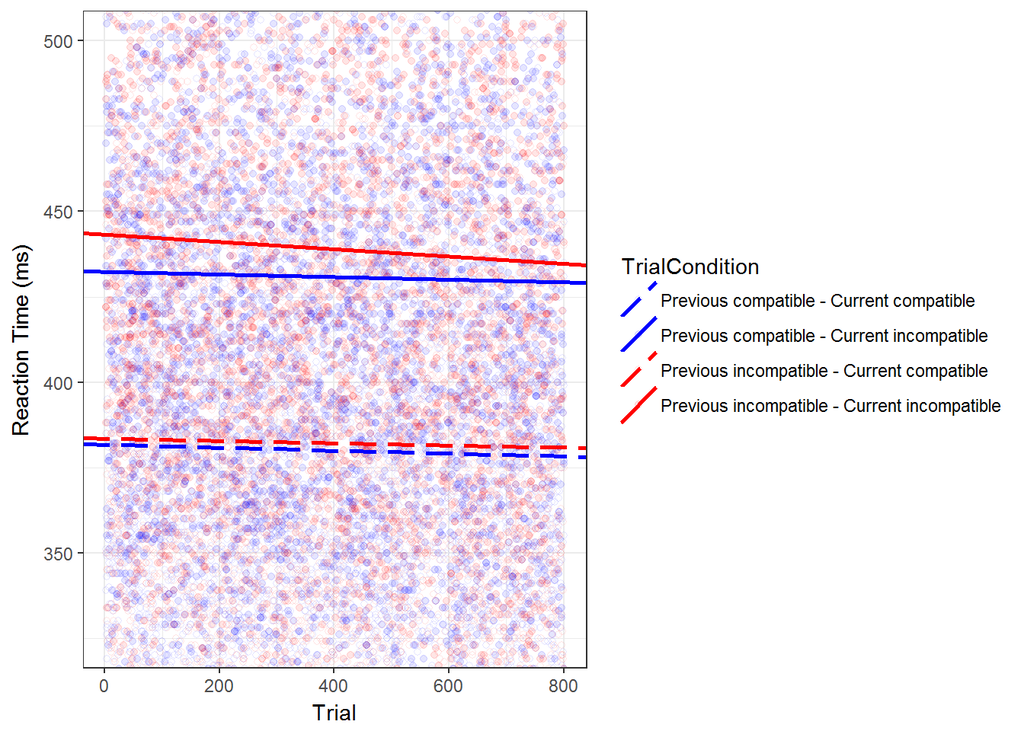

##### Simple slopes

Trial is scaled to range from 0 to 8 (instead of 1 to 800) so that the betas associated with trial are a little bigger (but significance testing is unaffected by linear scaling, so the test statistics and p values will be the same as if we used the unscaled Trial variable).

| Estimate | SE | ci95_lower | ci95_upper | Current | Previous | Color |
| --- | --- | --- | --- | --- | --- | --- |
| -0.447 | 0.517 | -1.48 | 0.5869 | Compat | Compat | blue dashed |
| -0.338 | 0.548 | -1.43 | 0.7579 | Compat | Incompat | red dashed |
| -0.389 | 0.546 | -1.48 | 0.7035 | Incompat | Compat | blue solid |
| -1.053 | 0.568 | -2.19 | 0.0837 | Incompat | Incompat | red solid |

##### Fixed effects of Trial and interactions with Trial:

Trial is centered and scaled to range from -4 to 4.

|  | Estimate | Std. Error | df | t value | Pr(>\|t\|) |
| --- | --- | --- | --- | --- | --- |
| Trial.begin | -0.546 | 0.272 | 17299.81 | -2.003 | 0.045 |
| Current.e:Trial.begin | -0.158 | 0.272 | 17314.40 | -0.580 | 0.562 |
| Previous.e:Trial.begin | -0.142 | 0.273 | 17311.10 | -0.522 | 0.601 |
| Current.e:Previous.e:Trial.begin | -0.196 | 0.273 | 17301.01 | -0.718 | 0.473 |

##### Fixed effects at beginning of task:

|  | Estimate | Std. Error | df | t value | Pr(>\|t\|) |
| --- | --- | --- | --- | --- | --- |
| (Intercept) | 410.154 | 7.265 | 51.210 | 56.458 | 0.000 |
| Current.e | 27.508 | 1.931 | 101.163 | 14.242 | 0.000 |
| Previous.e | 3.170 | 1.288 | 557.347 | 2.460 | 0.014 |
| Current.e:Previous.e | 2.235 | 1.269 | 902.857 | 1.761 | 0.079 |

**Marginal means:**  
Error bars represent standard error.

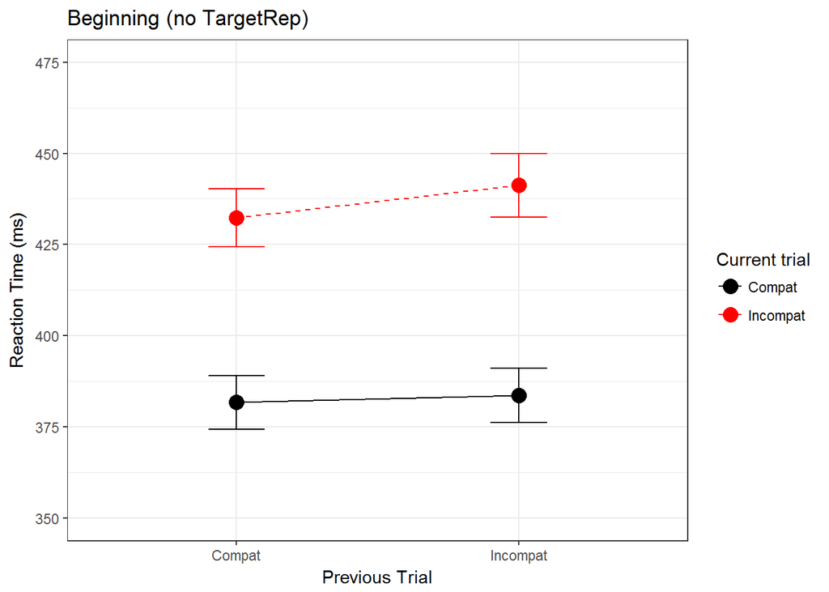

##### Fixed effects at middle of task:

|  | Estimate | Std. Error | df | t value | Pr(>\|t\|) |
| --- | --- | --- | --- | --- | --- |
| (Intercept) | 407.971 | 7.185 | 48.995 | 56.782 | 0.000 |
| Current.e | 26.875 | 1.605 | 48.334 | 16.740 | 0.000 |
| Previous.e | 2.600 | 0.711 | 53.041 | 3.655 | 0.001 |
| Current.e:Previous.e | 1.452 | 0.676 | 76.013 | 2.148 | 0.035 |

**Marginal means:**  
Error bars represent standard error.

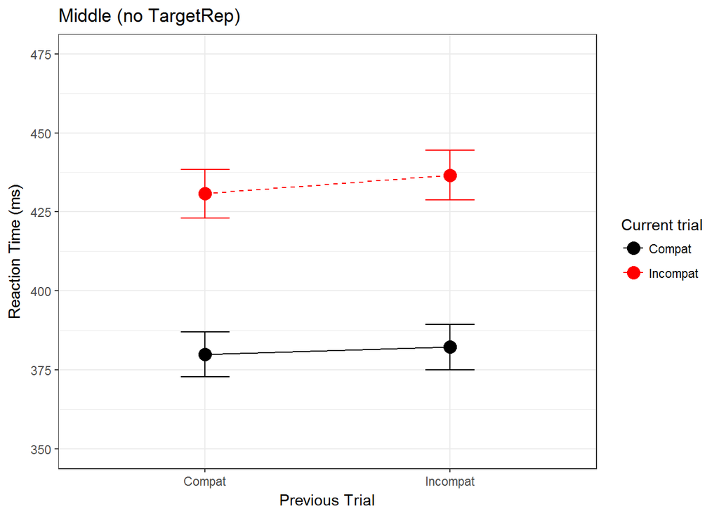

##### Fixed effects at end of task:

|  | Estimate | Std. Error | df | t value | Pr(>\|t\|) |
| --- | --- | --- | --- | --- | --- |
| (Intercept) | 405.787 | 7.270 | 51.342 | 55.820 | 0.000 |
| Current.e | 26.243 | 1.950 | 104.992 | 13.461 | 0.000 |
| Previous.e | 2.030 | 1.316 | 603.871 | 1.543 | 0.123 |
| Current.e:Previous.e | 0.669 | 1.297 | 977.494 | 0.515 | 0.606 |

**Marginal means:**  
Error bars represent standard error.

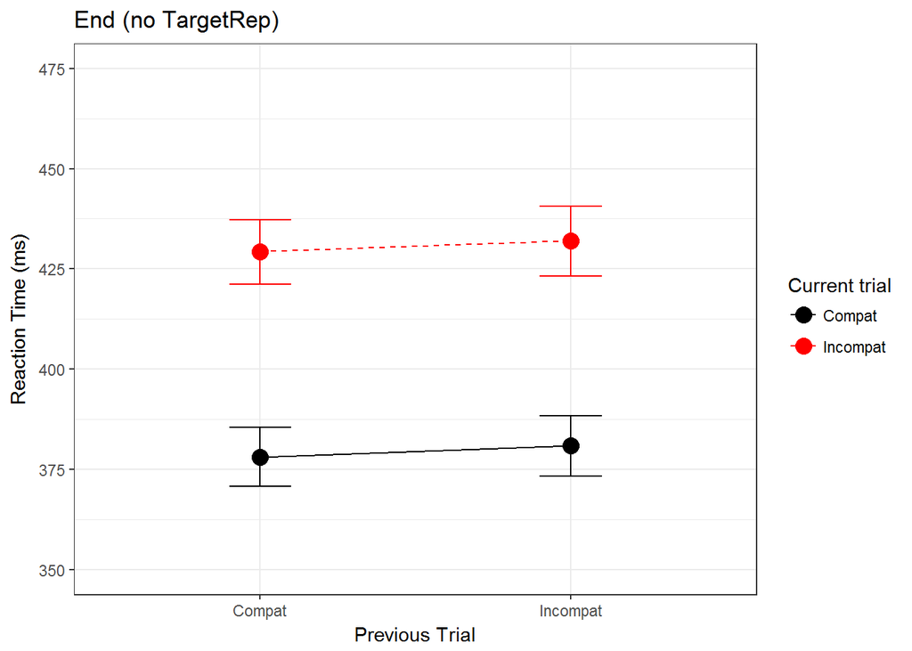

#### B. CompleteRep trials taken out

##### Plot over whole task

**Slopes and estimates of lines are from the MLM, not fitted with OLS.**

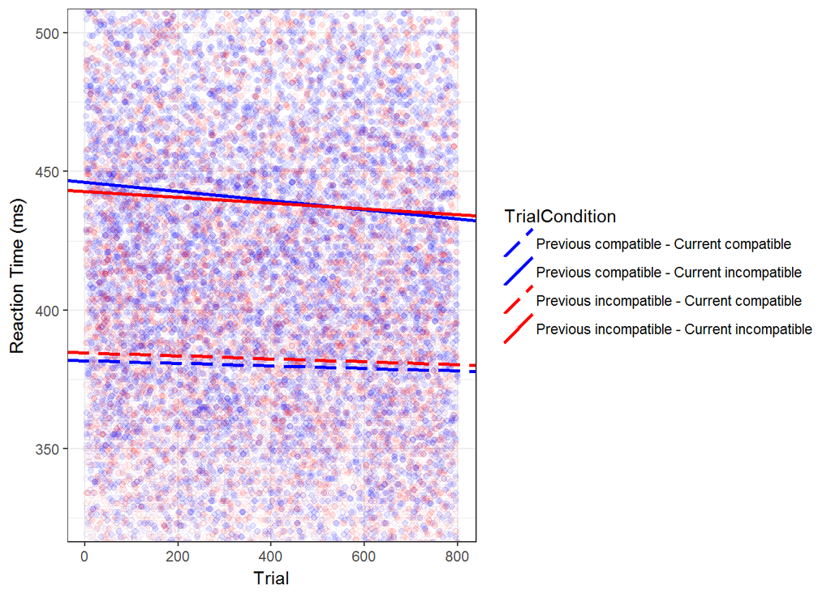

##### Simple slopes

Trial is scaled to range from 0 to 8 (instead of 1 to 800) so that the betas associated with trial are a little bigger (but significance testing is unaffected by linear scaling, so the test statistics and p values will be the same as if we used the unscaled Trial variable).

| Estimate | SE | ci95_lower | ci95_upper | Current | Previous | Color |
| --- | --- | --- | --- | --- | --- | --- |
| -0.455 | 0.524 | -1.50 | 0.5920 | Compat | Compat | blue dashed |
| -0.542 | 0.390 | -1.32 | 0.2389 | Compat | Incompat | red dashed |
| -1.664 | 0.392 | -2.45 | -0.8792 | Incompat | Compat | blue solid |
| -1.053 | 0.575 | -2.20 | 0.0982 | Incompat | Incompat | red solid |

##### Fixed effects of Trial and interactions with Trial:

Trial is centered and scaled to range from -4 to 4.

|  | Estimate | Std. Error | df | t value | Pr(>\|t\|) |
| --- | --- | --- | --- | --- | --- |
| Trial.begin | -0.908 | 0.239 | 25851.42 | -3.804 | 0.000 |
| Current.e:Trial.begin | -0.416 | 0.239 | 25845.70 | -1.746 | 0.081 |
| Previous.e:Trial.begin | 0.143 | 0.239 | 25853.83 | 0.601 | 0.548 |
| Current.e:Previous.e:Trial.begin | 0.182 | 0.239 | 25842.72 | 0.761 | 0.447 |

##### Fixed effects at beginning of task:

|  | Estimate | Std. Error | df | t value | Pr(>\|t\|) |
| --- | --- | --- | --- | --- | --- |
| (Intercept) | 413.799 | 7.345 | 50.644 | 56.341 | 0.000 |
| Current.e | 30.649 | 1.740 | 96.628 | 17.618 | 0.000 |
| Previous.e | -0.107 | 1.128 | 1065.762 | -0.095 | 0.924 |
| Current.e:Previous.e | -1.505 | 1.249 | 254.430 | -1.205 | 0.229 |

**Marginal means:**  
Error bars represent standard error.

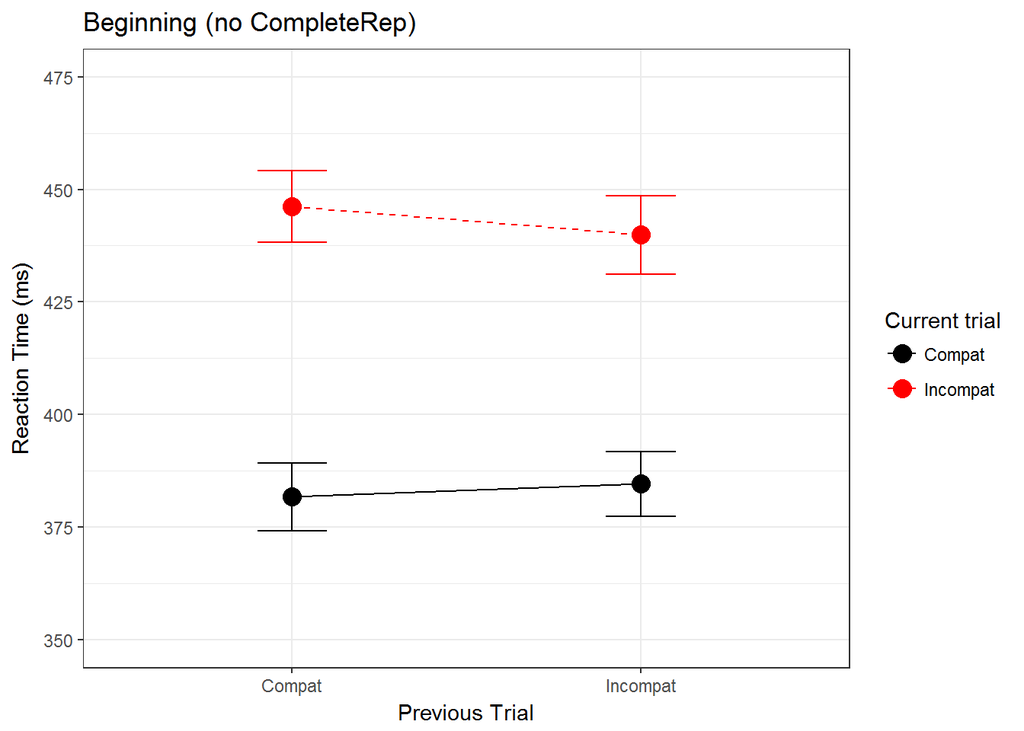

##### Fixed effects at middle of task:

|  | Estimate | Std. Error | df | t value | Pr(>\|t\|) |
| --- | --- | --- | --- | --- | --- |
| (Intercept) | 410.169 | 7.284 | 49.003 | 56.308 | 0.000 |
| Current.e | 28.983 | 1.465 | 48.568 | 19.789 | 0.000 |
| Previous.e | 0.467 | 0.624 | 103.818 | 0.747 | 0.456 |
| Current.e:Previous.e | -0.779 | 0.823 | 48.282 | -0.946 | 0.349 |

**Marginal means:**  
Error bars represent standard error.

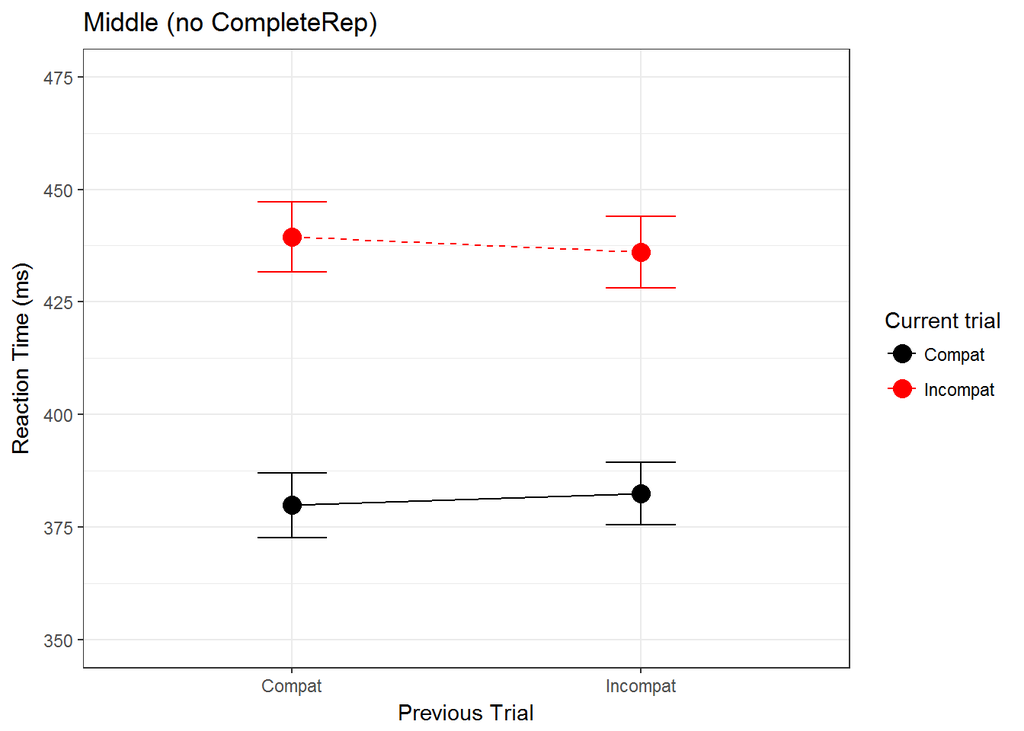

##### Fixed effects at end of task:

|  | Estimate | Std. Error | df | t value | Pr(>\|t\|) |
| --- | --- | --- | --- | --- | --- |
| (Intercept) | 406.539 | 7.349 | 50.752 | 55.322 | 0.000 |
| Current.e | 27.318 | 1.756 | 100.340 | 15.554 | 0.000 |
| Previous.e | 1.040 | 1.153 | 1155.210 | 0.902 | 0.367 |
| Current.e:Previous.e | -0.052 | 1.272 | 273.231 | -0.041 | 0.967 |

**Marginal means:**  
Error bars represent standard error.

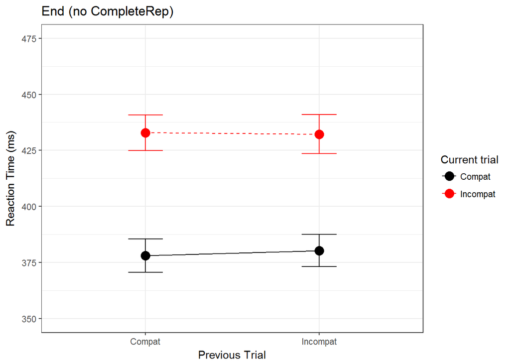

#### C. TargetRep trials retained, included as covariate

##### Plot over whole task, separately for TargetRep and non-TargetRep

**Slopes and estimates of lines are from the MLM, not fitted with OLS.**

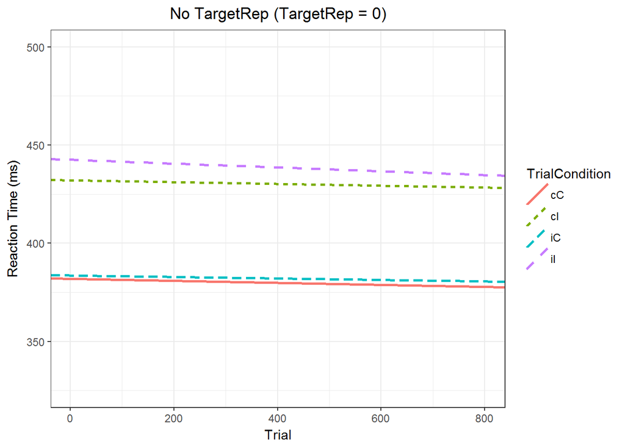

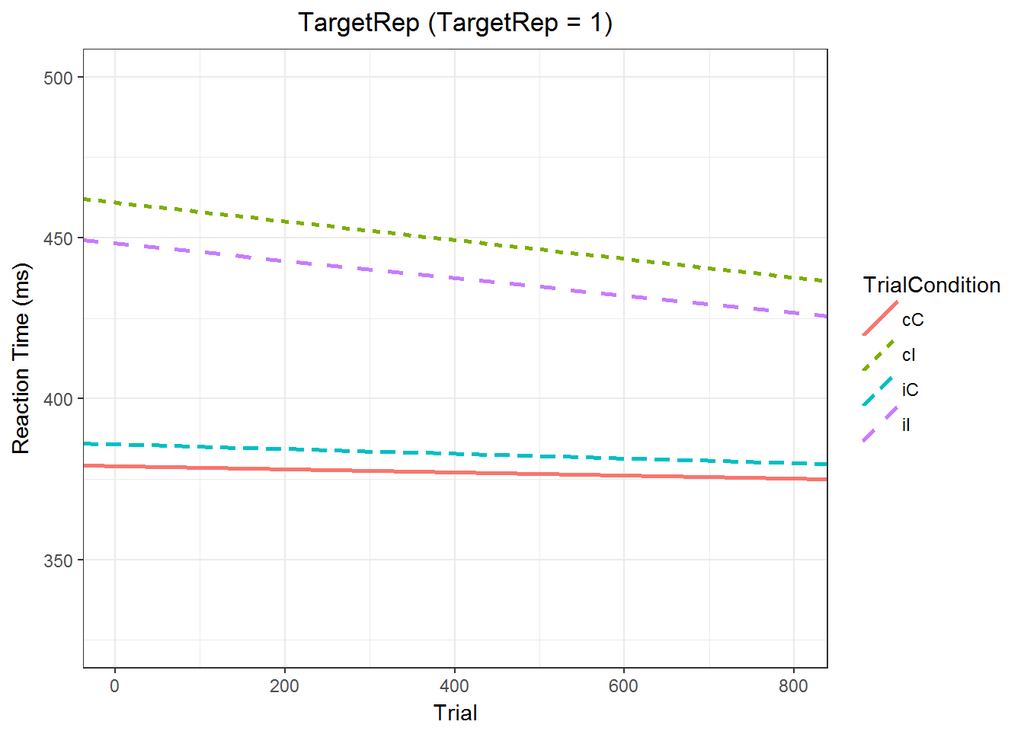

##### Beginning of the task

Current and Previous are effect coded, trial ranges from 0 to 8.

|  | Estimate | Std. Error | df | t value | Pr(>\|t\|) |
| --- | --- | --- | --- | --- | --- |
| (Intercept) | 409.959 | 7.445 | 51.531 | 55.063 | 0.000 |
| Current.e | 27.330 | 1.256 | 34316.897 | 21.755 | 0.000 |
| Previous.e | 3.065 | 1.256 | 34316.947 | 2.440 | 0.015 |
| Current.e:Previous.e | 2.210 | 1.257 | 34317.080 | 1.759 | 0.079 |

|  | Estimate | Std. Error | df | t value | Pr(>\|t\|) |
| --- | --- | --- | --- | --- | --- |
| Trial.begin | -0.577 | 0.275 | 34316.96 | -2.098 | 0.036 |
| Current.e:Trial.begin | -0.146 | 0.275 | 34316.87 | -0.529 | 0.597 |
| Previous.e:Trial.begin | -0.101 | 0.275 | 34316.93 | -0.368 | 0.713 |
| Current.e:Previous.e:Trial.begin | -0.160 | 0.275 | 34317.13 | -0.582 | 0.561 |
| Trial.begin:TargetRep | -1.129 | 0.391 | 34317.11 | -2.887 | 0.004 |
| Current.e:Trial.begin:TargetRep | -0.947 | 0.391 | 34316.98 | -2.423 | 0.015 |
| Previous.e:Trial.begin:TargetRep | 0.092 | 0.391 | 34317.09 | 0.234 | 0.815 |
| Current.e:Previous.e:Trial.begin:TargetRep | 0.272 | 0.391 | 34317.11 | 0.695 | 0.487 |

|  | Estimate | Std. Error | df | t value | Pr(>\|t\|) |
| --- | --- | --- | --- | --- | --- |
| TargetRep | 8.520 | 1.785 | 34317.10 | 4.772 | 0.000 |
| Current.e:TargetRep | 8.651 | 1.785 | 34317.00 | 4.847 | 0.000 |
| Previous.e:TargetRep | -4.561 | 1.785 | 34317.11 | -2.554 | 0.011 |
| Current.e:Previous.e:TargetRep | -7.062 | 1.785 | 34317.10 | -3.955 | 0.000 |

##### Middle of the task

Current and Previous are effect coded, trial ranges from -4 to 4.

|  | Estimate | Std. Error | df | t value | Pr(>\|t\|) |
| --- | --- | --- | --- | --- | --- |
| (Intercept) | 407.649 | 7.366 | 49.366 | 55.343 | 0.000 |
| Current.e | 26.747 | 0.634 | 34337.280 | 42.183 | 0.000 |
| Previous.e | 2.660 | 0.634 | 34337.388 | 4.194 | 0.000 |
| Current.e:Previous.e | 1.569 | 0.634 | 34337.282 | 2.475 | 0.013 |

|  | Estimate | Std. Error | df | t value | Pr(>\|t\|) |
| --- | --- | --- | --- | --- | --- |
| TargetRep | 4.005 | 0.903 | 34337.63 | 4.435 | 0 |
| Current.e:TargetRep | 4.864 | 0.903 | 34337.34 | 5.389 | 0 |
| Previous.e:TargetRep | -4.194 | 0.903 | 34337.51 | -4.645 | 0 |
| Current.e:Previous.e:TargetRep | -5.975 | 0.903 | 34337.33 | -6.620 | 0 |

##### End of the task

Current and Previous are effect coded, trial ranges from -8 to 0.

|  | Estimate | Std. Error | df | t value | Pr(>\|t\|) |
| --- | --- | --- | --- | --- | --- |
| (Intercept) | 405.339 | 7.450 | 51.656 | 54.408 | 0.000 |
| Current.e | 26.165 | 1.284 | 34347.315 | 20.374 | 0.000 |
| Previous.e | 2.254 | 1.284 | 34347.415 | 1.755 | 0.079 |
| Current.e:Previous.e | 0.928 | 1.285 | 34347.528 | 0.723 | 0.470 |

|  | Estimate | Std. Error | df | t value | Pr(>\|t\|) |
| --- | --- | --- | --- | --- | --- |
| TargetRep | -0.509 | 1.826 | 34347.66 | -0.279 | 0.780 |
| Current.e:TargetRep | 1.077 | 1.825 | 34347.41 | 0.590 | 0.555 |
| Previous.e:TargetRep | -3.827 | 1.826 | 34347.54 | -2.097 | 0.036 |
| Current.e:Previous.e:TargetRep | -4.888 | 1.825 | 34347.50 | -2.677 | 0.007 |